# Breve análise setorial da economia de SC

Guilherme Viegas

15/03/2020

#### Florianópolis tambem é conhecida como a Capital da Inovação devido ao polo tecnológico que se concentra, especialmente, na própria cidade. Muitos constumam afirmar que toda a metropole comporta este polo, mas, como podemos observar no dados, São José e Palhoça ainda estão consideravelmente atrás da capital. São José, no ano de 2017, representou apenas 10.141% dos postos de emprego em comparação com a capital e palhoça 3.836% em comparação com a mesma.

| Ano | Florinópolis | São José | Palhoça | Biguaçu |
| --- | --- | --- | --- | --- |
| 2010 | 4819 | 313 | 15 | 3 |
| 2011 | 4042 | 352 | 12 | 4 |
| 2012 | 5271 | 497 | 157 | 4 |
| 2013 | 5313 | 403 | 40 | 65 |
| 2014 | 5700 | 367 | 59 | 67 |
| 2015 | 5690 | 450 | 122 | 5 |
| 2016 | 5823 | 588 | 122 | 10 |
| 2017 | 6518 | 661 | 250 | 13 |

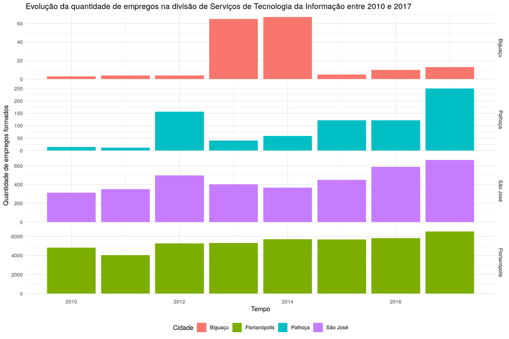

#### Se aplicarmos uma regressão linear na série ‘número de empregos em Serviços de Tecnologia da Informação na cidade de Florianópolis’, chegaríamos a um coeficiente angular de 267. Ou seja, há potencialmente um aumento de 267 empregos ao ano. Vale notar que o p-valor do teste t de significância do coeficiente angular é igual a 0.003, altamente significativo. Claro, outras hipóteses tambem devem ser confirmadas para validarmos o modelo.

##### Em 2014, mais ao norte do estado, a fábrica da BMW já passa a não ser mais uma novidade para os moradores da pequena cidade de Araquarí, que tem pouco mais de 30000 habitantes. Como podemos observar no gráfico a seguir, o nível de exportação da cidade cresceu vertiginosamente após a chegada da fábrica, especialmente para os estados unidos da américa do norte.

#### De acordo com a revista [Exame](https://exame.abril.com.br/negocios/por-dentro-da-fabrica-da-bmw-em-sc/), “A produção na fábrica do BMW Group em Araquari (SC) segue o princípio ‘build-to-stock’. Ou seja, a produção de veículos no local é baseada em dados de vendas e de acordo com o volume de demanda.” O investimento realizado na fabrica foi de mais de 600 milhões de reais, resultando em possíveis 1300 empregos diretos e 2500 indiretos, quando funcionando em plena capacidade.

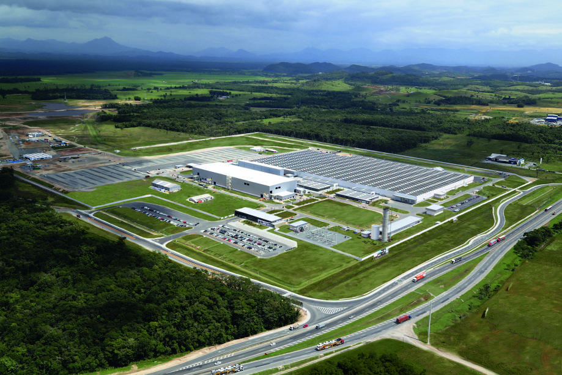

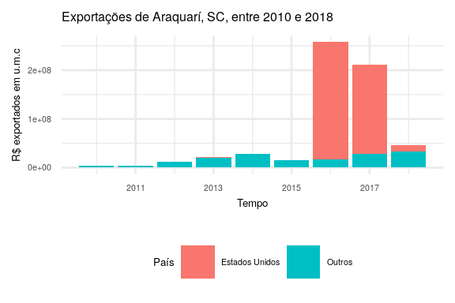

#### Por fim, ao analisarmos a distribuição das conexões dos produtos de Santa Catarina com escopo doméstico, percebemos que há considerável disperção entre eles. O estado Catarinenese há anos vem ganhando destaque na produção de aves, carne bovina e suína, produtos texteis, produtos de cerâmica, motores e maquinários diversos.

### Espaço de Produtos para Santa Catarina(2017)

#### Baseado nos Estados Produtores

#### Exportações: $8,51 Bilhões USD

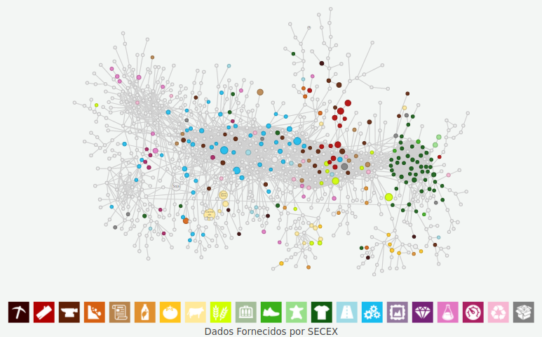